# Data prep

Set working directory

```r
# getwd()
setwd("./Data")
# getwd()
```

Install the libraries

```r
require(data.table)
require(kmed)
require(tm)
require(devtools)
require(Rcpp)
require(rmarkdown)
require(clv)
require(text2vec)
require(text2vec)
```

Import the data

```r
query_dt <- fread("C:/Users/harika/Desktop/interview prep/dubbizle/Data/za_queries_sample.csv")
listings_dt <- fread("C:/Users/harika/Desktop/interview prep/dubbizle/Data/za_sample_listings_incl_cat.csv")
```

```
##
Read 40.3% of 571244 rows
Read 71.8% of 571244 rows
Read 500000 rows and 12 (of 12) columns from 0.128 GB file in 00:00:04
```

Summary of the datasets

```r
head(query_dt)
```

```
##    V1    search_term    cnt
## 1:  0           polo 133394
## 2:  1           golf 124172
## 3:  2          isuzu 121043
## 4:  3            bmw 109099
## 5:  4 toyota corolla 107486
## 6:  5         toyota  99802
```

```r
nrow(query_dt)
```

```
## [1] 100000
```

```r
length(unique(query_dt$search_term))
```

```
## [1] 100000
```

```r
head(listings_dt)
```

```
##    V1 item_id seller_id
## 1:  0       0         0
## 2:  1       1         1
## 3:  2       2         2
## 4:  3       3         3
## 5:  4       4         4
## 6:  5       5         5
##                                                            listing_title
## 1:                                                     Nice wooden makes
## 2: A Shinning 2013 Chevrolet 1.4 Utility Bakkie with FSH amd all extras!
## 3:                                                    Lampshades various
## 4:                                                        Toyota Corolla
## 5:                                              bench grinder and buffer
## 6:                                                  louvre wendies R4700
##                                                                                                                                                                           listing_description
```

[output cut: 27 more lines]

```r
length(unique(listings_dt$category_l1_name_en))
```

```
## [1] 13
```

```r
length(unique(listings_dt$category_l2_name_en))
```

```
## [1] 55
```

```r
length(unique(listings_dt$category_l3_name_en))
```

```
## [1] 271
```

```r
listings_dt[,.N, by = category_l2_name_en]
```

```
##                       category_l2_name_en      N
##  1:                        Garden & Braai   5703
##  2:                        Cars & Bakkies 155155
##  3:                     Furniture & Decor  31555
##  4:                           Tools & DIY   9162
##  5:                 Homeware & Appliances  15305
##  6:                             Transport   5085
##  7:               Car Parts & Accessories  37308
##  8:               Houses & Flats for sale   3628
##  9:            Health, Beauty & Cosmetics   3574
## 10:       Computer Hardware & Accessories   6328
## 11:                           Cell Phones  28266
## 12:          Office Furniture & Equipment   2567
## 13:                Pet Care & Accessories   1737
## 14:                           Dogs & Cats   7170
```

[output cut: 42 more lines]

Check the sub groups within each category level2. Looks like except for vehicles, the category level 3 is not populated

```r
listings_dt[,.N, by = category_l2_name_en]
```

```
##                       category_l2_name_en      N
##  1:                        Garden & Braai   5703
##  2:                        Cars & Bakkies 155155
##  3:                     Furniture & Decor  31555
##  4:                           Tools & DIY   9162
##  5:                 Homeware & Appliances  15305
##  6:                             Transport   5085
##  7:               Car Parts & Accessories  37308
##  8:               Houses & Flats for sale   3628
##  9:            Health, Beauty & Cosmetics   3574
## 10:       Computer Hardware & Accessories   6328
## 11:                           Cell Phones  28266
## 12:          Office Furniture & Equipment   2567
## 13:                Pet Care & Accessories   1737
## 14:                           Dogs & Cats   7170
```

[output cut: 42 more lines]

```r
listings_dt[,.N, by = .(category_l2_name_en,category_l3_name_en)][,.N,by = .(category_l2_name_en)]
```

```
##                       category_l2_name_en  N
##  1:                        Garden & Braai  1
##  2:                        Cars & Bakkies 54
##  3:                     Furniture & Decor  1
##  4:                           Tools & DIY  1
##  5:                 Homeware & Appliances  1
##  6:                             Transport  1
##  7:               Car Parts & Accessories  1
##  8:               Houses & Flats for sale  1
##  9:            Health, Beauty & Cosmetics  1
## 10:       Computer Hardware & Accessories  1
## 11:                           Cell Phones  1
## 12:          Office Furniture & Equipment  1
## 13:                Pet Care & Accessories  1
## 14:                           Dogs & Cats  1
```

[output cut: 42 more lines]

Building the model at a category level 1 will not be granular enough. Category level 3 doesn’t have good coverage. So the clustering will be done for each category level2. Test the approach/model on one category

```r
listings_test <- listings_dt[category_l2_name_en == "iPads & Tablets"]
# combine the title and the descriptions
listings_test[, listing_title_desc := paste(listing_title, listing_description)]
```

Combination of listing title and description is considered to extract the features. It can also be useful to give more weight to title compared to description.

```r
corpus <- Corpus(VectorSource(listings_test$listing_title_desc))
dtm <- DocumentTermMatrix(corpus, control = list(removePunctuation = TRUE
                                                 , stopwords = TRUE
                                                 ,weighting = weightTfIdf)
                          )
dim(dtm)
```

```
## [1] 3036 4836
```

```r
inspect(dtm)
```

```
## <<DocumentTermMatrix (documents: 3036, terms: 4836)>>
## Non-/sparse entries: 42475/14639621
## Sparsity           : 100%
## Maximal term length: 69
## Weighting          : term frequency - inverse document frequency (normalized) (tf-idf)
## Sample             :
##       Terms
## Docs   apple condition galaxy good ipad new samsung tab tablet wifi
##   1075     0         0      0    0    0   0       0   0      0    0
##   13       0         0      0    0    0   0       0   0      0    0
##   1758     0         0      0    0    0   0       0   0      0    0
##   213      0         0      0    0    0   0       0   0      0    0
##   2202     0         0      0    0    0   0       0   0      0    0
##   249      0         0      0    0    0   0       0   0      0    0
##   2495     0         0      0    0    0   0       0   0      0    0
##   2596     0         0      0    0    0   0       0   0      0    0
##   2997     0         0      0    0    0   0       0   0      0    0
##   663      0         0      0    0    0   0       0   0      0    0
```

```r
dtm <- removeSparseTerms(dtm, .999)
dim(dtm)
```

```
## [1] 3036 1185
```

Using all factors will not give enough weight to factors like price and location.Instead of using price and location to calculate an overall distance, seperate distances were calculated for features (text words), price and location. Further the distances were scaled using the maximum or 90% percentile distance and a weighted average is applied to calculate the final distance

```r
dist_dtm <- sqrt(distNumeric(as.matrix(dtm), as.matrix(dtm), method = "se"))
max(dist_dtm)
```

```
## [1] 6.568179
```

```r
min(dist_dtm)
```

```
## [1] 0
```

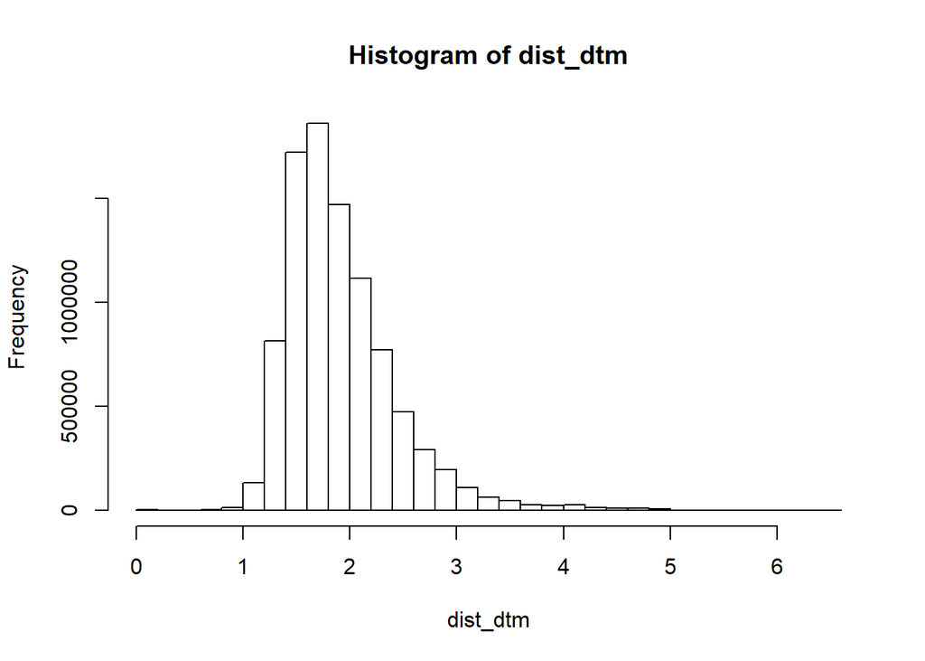

```r
hist(dist_dtm)
```

```r
quantile(dist_dtm, probs = c(0.99), na.rm = TRUE)
```

```
##      99%
## 3.836943
```

```r
dist_dtm <- dist_dtm/max(dist_dtm)
```

Distance calculation based on price

```r
dist_price <- sqrt(distNumeric(as.matrix(listings_test[,.(listing_price)])
                          ,as.matrix(listings_test[,.(listing_price)]), method = "se"))
max(dist_price)
```

```
## [1] 164999
```

```r
min(dist_price)
```

```
## [1] 0
```

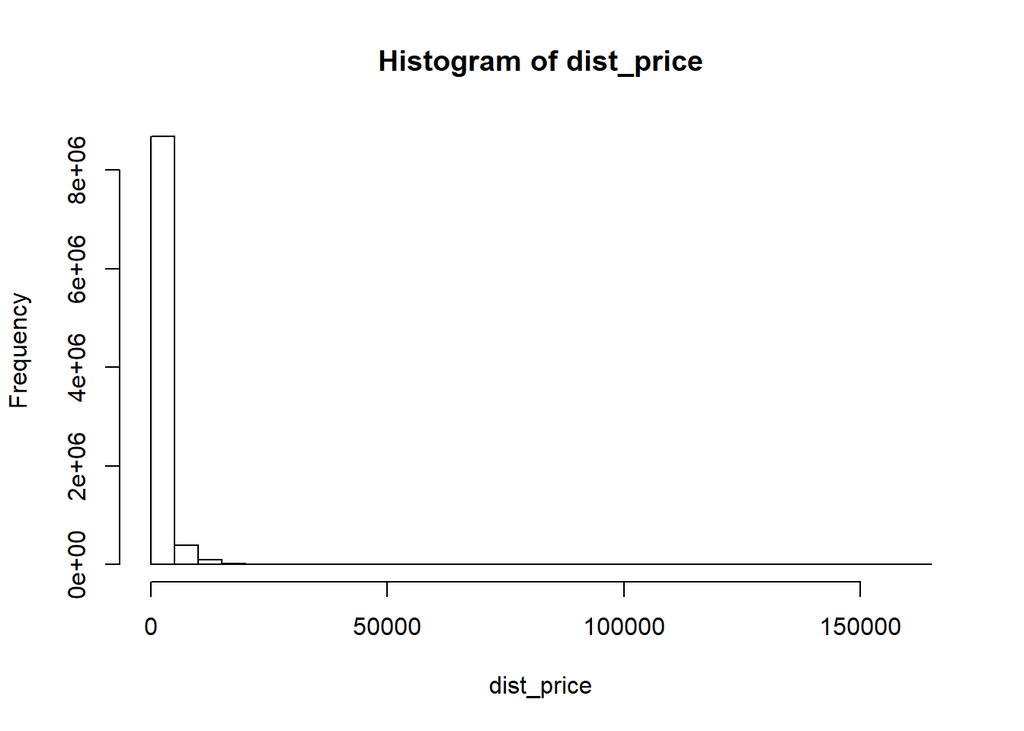

```r
hist(dist_price)
```

```r
dist_price_cap <- quantile(dist_price, probs = c(0.90), na.rm = TRUE)
dist_price_cap
```

```
##  90%
## 3851
```

```r
dist_price <- dist_price/dist_price_cap
```

Distance calculation based on geo coordinates

```r
dist_loc <- sqrt(distNumeric(as.matrix(listings_test[,.(listing_latitude, listing_longitude)])
                        ,as.matrix(listings_test[,.(listing_latitude, listing_longitude)]), method = "se"))
max(dist_loc)
```

```
## [1] 17.01422
```

```r
min(dist_loc)
```

```
## [1] 0
```

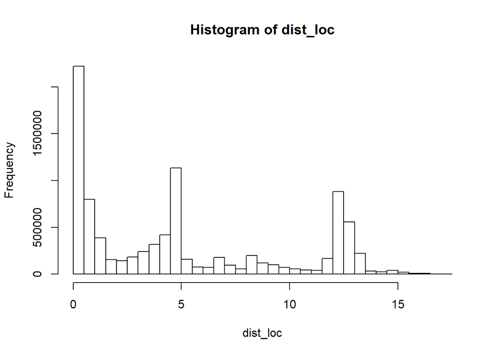

```r
hist(dist_loc) # doesnt have outliers
```

```r
dist_loc <- dist_loc/max(dist_loc)
```

Weighted average of the distances. Idea is to give more importance to text similarity and price. Although, this can be changed based on business knowledge.

```r
w1 <- 0.4
w2 <- 0.4
w3 <- 0.2
dist_comb <- w1*dist_dtm + w2*dist_price + w3*dist_loc
```

```r
ncluster <- round(nrow(dtm)/50)
```

**K-means clustering was not considered as it uses only euclidean distance and customised distances can not be used in k-means and so k-mediods is considered**

```r
result <- fastkmed(dist_comb, ncluster = ncluster, iterate = 10)
```

Join the results to the base table

```r
listings_test[, cluster := NULL]
listings_test <- cbind(listings_test, cluster = result$cluster)
listings_test[,.N,by = cluster]
```

```
##     cluster   N
##  1:      41  87
##  2:      38 143
##  3:      40 181
##  4:      56 256
##  5:      50  92
##  6:       2 137
##  7:      48  39
##  8:       6 157
##  9:       9  23
## 10:      17 113
## 11:      15   6
## 12:      33  47
## 13:      23 135
## 14:      37  22
```

[output cut: 48 more lines]

Manually see the items in the clusters

```r
head(listings_test)
```

```
##      V1 item_id seller_id
## 1:  122     122       120
## 2: 1525    1525      1472
## 3: 1586    1586      1527
## 4: 1603    1603      1048
## 5: 1852    1852      1761
## 6: 1875    1875      1782
##                                               listing_title
## 1:                          Samsung Galaxy Tab A with S pen
## 2:                                   Samsung S4 for sale!!!
## 3: Hi im,selling samsung tab 6a (2016) im based at mzingazi
## 4:                                       Vodafone Tab 7inch
## 5:                         Apple 30-pin iPad to VGA adapter
## 6:                                     Samsung galaxy tab 3
##                                                                                                                                                                                                                                                             listing_description
```

[output cut: 41 more lines]

Cluster group and the data of the mediod of the cluster is to be saved

```r
cluster_dt <- cbind(cluster = result$cluster, mediod = result$mediod)
```

**Mapping new listings** When a new listing is added, then the distance to the centroids of each of the cluster is computed based on td-idf, price and location. The cluster which is closest to the new listing is updated in the dataset.

**Evaluation of the above approach** Cluster evaluation can be done two ways internal and external measures. Use A/B testing and compare metrics like click-through rate, watch rate etc. External measures can be implemented for the cases of known classes and internal measures use metrics such as intra cluster similarity.

Compute overall similarity in naive approach. Treating the whole as single cluster

```r
# similarity
similarity_overall <- sim2(x = as.matrix(dtm), method = "cosine", norm = "l2")
sum(similarity_overall[upper.tri(similarity_overall,diag = FALSE)])
```

```
## [1] 182659.8
```

```r
mean(similarity_overall[upper.tri(similarity_overall,diag = FALSE)])
```

```
## [1] 0.03964719
```

Compute similarity within clusters

```r
dm = cbind(as.matrix(dtm), cluster = listings_test$cluster)
no_cls <- length(unique(listings_test$cluster))
dt_overall <- NULL
for (i in 1:no_cls){
  cluster <- i
  count <- nrow(as.matrix(subset(dm, dm[,"cluster"] == i)))
  similarity <- sim2(x = as.matrix(subset(dm, dm[,"cluster"] == i)), method = "cosine", norm = "l2")
  simi_total <- sum(similarity[upper.tri(similarity,diag = FALSE)])
  simi_avg <- mean(similarity[upper.tri(similarity,diag = FALSE)])
  dt <- data.table(cluster = cluster, count = count, simi_total = simi_total, simi_avg = simi_avg)
  dt_overall <- rbind(dt_overall,dt)
}
setorder(dt_overall,-count)
dt_overall
```

```
##     cluster count   simi_total  simi_avg
##  1:      56   256 3.261376e+04 0.9991961
##  2:      40   181 1.627134e+04 0.9988547
##  3:      34   180 1.608659e+04 0.9985467
##  4:       6   157 1.156968e+04 0.9447719
##  5:      38   143 1.014006e+04 0.9987255
##  6:       2   137 6.688841e+03 0.7179950
##  7:      23   135 9.014824e+03 0.9966637
##  8:      17   113 6.292344e+03 0.9943654
##  9:      54    94 4.368740e+03 0.9994830
## 10:       4    92 3.749240e+03 0.8956617
## 11:      50    92 4.181045e+03 0.9988164
## 12:      26    87 3.732193e+03 0.9976457
## 13:      41    87 3.736790e+03 0.9988747
## 14:      19    77 2.912113e+03 0.9952539
```

[output cut: 48 more lines]

**Extentions of the above approach** Using search data to weigh the keywords i.e.higher weights to keywords which appear frequently in the search. Explore other clustering techniques for silimarity of text tokens. It is right now based on single-gram. Stemming can improve the td-idf matrix and the clustering